# Estruturas de Armazenamento e Gráficos - BÁSICO

Cleber Almeida Pereira

30/04/2021

# Apresentação

> A **linguagem R** é uma linguagem de programação utilizada para análises estatísticas e representação através de gráficos.

> Este material foi desenvolvido utilizando o **RStudio** Version 1.3.1093, através da ferramenta **R Markdown**.

> O **RStudio** facilita o uso da **linguagem R** através de uma interface gráfica para manipulação de dados, cálculos estatísticos e criação de gráficos.

> O intuito é apresentar algumas estruturas de armazenamento e usos básicos destas estruturas de um modo que pode ser aplicado em *Data Science* nos processos de análises de dados e representação gráfica destes.

# Estruturas de Armazenamento

> Nesta seção apresentaremos:
- Vetor
- Fator
- Lista
- Data frame
- Matriz

> Importante destacar que, diferente de outras linguagens de programação, em **R** o primeiro índice é **1** e não **0**.

## 1. Vetor

> Todos os elementos devem ser do mesmo tipo.

> Criaremos 2 vetores, sendo o primeiro com nome de cidades e o segundo com siglas de unidades da federação (UF) das cidades criadas.

### a. declarar um Vetor

> Como exemplo vamos declarar um vetor com nome de quatro cidades do estado de Mato Grosso do Sul (BRASIL):

> ```r
> cidades <- c("Campo Grande", "Corumbá", "Ladário", "Miranda")
> cidades
> ```

> ```
> ## [1] "Campo Grande" "Corumbá"      "Ladário"      "Miranda"
> ```

> > Na saída do código (**##**) são exibidos os valores do nosso vetor com índice máximo igual a 4, ou seja, contendo 4 elementos.

### b. acessar valor pelo índice

> ```r
> cidades[3]
> ```

> ```
> ## [1] "Ladário"
> ```

> ```r
> cidades[0]
> ```

> ```
> ## character(0)
> ```

> > Note que, ao utilizar índice **0** nos foi retornada a informação do tipo de dado armazenado, no caso tipo *character*.  
> > Assim, ao declar um vetor com números (ex: c(1,2,3,4)), ao acessar o índice **0** será obtido como retorno o tipo *numeric*.

> ```r
> cidades[5]
> ```

> ```
> ## [1] NA
> ```

> > No exemplo acima, foi utilizado índice 5, no caso um índice inexistente, sendo apresentado saída com valor **NA** para indicar que não há resposta disponível.  
> > **NA** significa *not applicable* (não aplicável ou não se aplica), *not available* (não disponível) ou *no answer* (sem resposta).

### c. atualizar o valor de um índice existente

> ```r
> cidades[4] <- "Aquidauana"
> cidades
> ```

> ```
> ## [1] "Campo Grande" "Corumbá"      "Ladário"      "Aquidauana"
> ```

> > Ao exibir os valores do vetor podemos observar que foi alterado o nome da cidade do índice 4, que antes era “Miranda” e agora é “Aquidauana”.

### d. adicionar novo índice e atribuir um valor

> ```r
> cidades[5] <- "Miranda"
> cidades
> ```

> ```
> ## [1] "Campo Grande" "Corumbá"      "Ladário"      "Aquidauana"   "Miranda"
> ```

> > Foi adicionado o município “Miranda” no índice 5.  
> > É preciso saber o tamanho do vetor para evitar atribuir valor a um índice já existente.  
> > Outro erro que pode acontecer é informar um índice muito longe criando uma série de índices novos e fazendo com que o valor seja atribuído a todos os índices novos.  
> > Utilizando o vetor **cidades** como exemplo, se ao invés de informar índice 5 o usuário tivéssemos informado índice 10, teríamos criados todos os índices inexistentes, ou seja, de 5 a 10 e atribuído o valor “Miranda” a cada um deles.

### e. acessar um intervalo de valores

> ```r
> cidades[2:4]
> ```

> ```
> ## [1] "Corumbá"    "Ladário"    "Aquidauana"
> ```

> > Na saída estão exibidos os nomes dos municípios dos índices do intervalo 2 a 4.

### f. omitir um elemento do vetor

> ```r
> cidades[-4]
> ```

> ```
> ## [1] "Campo Grande" "Corumbá"      "Ladário"      "Miranda"
> ```

> > Indicamos o índice que não queremos utilizando o sinal **-** antes do índice.  
> > Observe que na saída não foi exibido o 4º elemento, “Aquidauana”.

### g. remover um elemento do vetor

> ```r
> cidades[6] <- "Whashington"
> cidades
> ```

> ```
> ## [1] "Campo Grande" "Corumbá"      "Ladário"      "Aquidauana"   "Miranda"
> ## [6] "Whashington"
> ```

> ```r
> cidades <- cidades[-6]
> cidades
> ```

> ```
> ## [1] "Campo Grande" "Corumbá"      "Ladário"      "Aquidauana"   "Miranda"
> ```

> > Primeiro foi atribuído o nome da cidade “Whashington” ao índice 6 e na saída foram exibidos todos os elementos do vetor.  
> > Para remover este último nome inserido, vamos utilizar uma técnica bem simples.  
> > Vamos atribuir o próprio vetor exceto o índice indicado com sinal negativo **-** como vimos anteriormente.

### h. limpar o vetor

> ```r
> cidades <- NULL # Limpa o vetor
> cidades
> ```

> > Para limpar o vetor atribuímos o valor **NULL** (nulo).

### i. declarando nosso segundo vetor (Sigla dos Estados)

> Para as próximas estruturas precisaremos representar a sigla dos estados para cada município do vetor **cidades**, então vamos criar um vetor com as siglas:

> ```r
> estados.sigla <- c("MS", "MS", "MS", "MS", "MS", "MS")
> estados.sigla
> ```

> ```
> ## [1] "MS" "MS" "MS" "MS" "MS" "MS"
> ```

> > Note que todos os estados são iguais.  
> > Se utilizarmos este vetor não poderemos apresentar um bom exemplo de análise por unidades da federação.  
> > Então vamos precisar criar cidades de outros estados brasileiros para podermos ter um melhor exemplo durante a análise.

> > Para isso adicionamos um conteúdo *bônus* logo a seguir.

## Bônus - Funções

> Vamos aproveitar a necessidade de utilizarmos outros municípios e siglas de unidades da federação e, ao invés de inserirmos novos municípios vamos alterar o conteúdo dos vetores **cidades** e **estados.sigla** utilizando funções.

> Para isso vamos criar duas funções próprias para atribuir os novos valores.  
> São funções com exemplos simples com um certo teor de revisão.

### Função: setar vetor *cidades*

> ```r
> set.vetor.cidades <- function(){
>  vetor_aux <- c("Campo Grande", "Cuiabá", "Curitiba", "Aquidauana")
>  vetor_aux[4] <- "São Paulo"
>  vetor_aux[5] <- "Miranda"
>  return(vetor_aux)
> }
> ```

> > Acima foi declarada uma função que não recebe nenhum argumento.  
> > Ela possui um vetor auxiliar que recebe os valores desejados e retorna este vetor quando solicitada.  
> > Nela escrevemos três linhas de atribuição apena para “revisar” um pouco do que vimos até agora.  
> > Observe que primeiro criamos um vetor com 4 cidades, depois alteramos o 4º elemento e, por fim atribuímos um 5º valor.

> Utilizamos a função criada atribuindo o seu retorno (*vetor_aux*) ao vetor **cidades** chamando-a como a seguir:

> ```r
> cidades <- set.vetor.cidades()
> cidades
> ```

> ```
> ## [1] "Campo Grande" "Cuiabá"       "Curitiba"     "São Paulo"    "Miranda"
> ```

> > Na saída apresentamos o novo conteúdo do vetor **cidades**.

### Função: setar vetor *estados.sigla*

> Agora precisamos alterar o conteúdo do vetor **estados.sigla** para que contenha os respectivos valores de UF para cada município do vetor **cidades**.  
> Para isso vamos criar uma função que altera aquele vetor.

> ```r
> set.vetor.estados.siglas <- function(){
>  vetor_aux <- c("MS", "MT", "PR", "SP", "MS")
>  return(vetor_aux)
> }
> ```

> > Como temos cinco cidades atribuímos respectivamente as cinco siglas de seus respectivos Estados.

> Assim como fizemos com o vetor **cidades** vamos chamar a função e alterar o conteúdo do vetor **estados.sigla**:

> ```r
> estados.sigla <- set.vetor.estados.siglas()
> estados.sigla
> ```

> ```
> ## [1] "MS" "MT" "PR" "SP" "MS"
> ```

> > Pronto, agora temos o registro de cinco cidades e suas respectivas unidades da federação.

> Mais adiante utilizaremos estes vetores na seção **Data frames**

## 2. Fator

> Esta função é utilizada para iterar sobre um **vetor**.  
> Basicamente, ela possibilita expressar uma variável categórica.

### a. declarar um Fator

> Como exemplo vamos usar a função sobre um vetor com siglas das Unidades da Federação.

> ```r
> siglas <- c("SP", "GO", "RS", "DF", "GO", "SP", "MS", "MT", "SP", "MS")
> UF <- as.factor(siglas)
> is.factor(UF)
> ```

> ```
> ## [1] TRUE
> ```

> ```r
> UF
> ```

> ```
> ##  [1] SP GO RS DF GO SP MS MT SP MS
> ## Levels: DF GO MS MT RS SP
> ```

> ```r
> UF[1]
> ```

> ```
> ## [1] SP
> ## Levels: DF GO MS MT RS SP
> ```

> ```r
> str(UF)
> ```

> ```
> ##  Factor w/ 6 levels "DF","GO","MS",..: 6 2 5 1 2 6 3 4 6 3
> ```

## 3. Lista

> São estruturas muito úteis pois podem armazenar objetos de diversos tipos.  
> Deste modo, as listas podem ser criadas contendo objetos de outras classes.

### a. criar uma lista de vários objetos

> Neste exemplo vamos criar uma lista contendo 2 vetores e um fator criados anteriormente.

> ```r
> lista <- list(cidades, estados.sigla, UF)
> lista
> ```

> ```
> ## [[1]]
> ## [1] "Campo Grande" "Cuiabá"       "Curitiba"     "São Paulo"    "Miranda"
> ##
> ## [[2]]
> ## [1] "MS" "MT" "PR" "SP" "MS"
> ##
> ## [[3]]
> ##  [1] SP GO RS DF GO SP MS MT SP MS
> ## Levels: DF GO MS MT RS SP
> ```

> ```r
> str(lista)
> ```

> ```
> ## List of 3
> ##  $ : chr [1:5] "Campo Grande" "Cuiabá" "Curitiba" "São Paulo" ...
> ##  $ : chr [1:5] "MS" "MT" "PR" "SP" ...
> ##  $ : Factor w/ 6 levels "DF","GO","MS",..: 6 2 5 1 2 6 3 4 6 3
> ```

> > Na última saída estão sendo exibidos os tipos de cada elemento desta lista.

### b. acessar um elemento da lista

> Vamos tentar acessar os elementos da lista que criamos acima.

> ```r
> lista$cidades
> ```

> ```r
> lista$estados.sigla
> ```

> ```r
> lista$UF
> ```

> ```r
> lista[1]
> ```

> ```
> ## [[1]]
> ## [1] "Campo Grande" "Cuiabá"       "Curitiba"     "São Paulo"    "Miranda"
> ```

> > Note que só foi possível acessar o valor através do índice da lista.  
> > O cifrão (**$**) é utilizado para indicar um elemento da lista, mas neste caso os objetos passados são atribuídos a cada índice.

> Então vamos criar outra lista.

> ```r
> pessoa <- list(nome="João",
>               sexo="M",
>               idade=42,
>               cidade="Campo Grande")
> pessoa
> ```

> ```
> ## $nome
> ## [1] "João"
> ##
> ## $sexo
> ## [1] "M"
> ##
> ## $idade
> ## [1] 42
> ##
> ## $cidade
> ## [1] "Campo Grande"
> ```

> ```r
> str(pessoa)
> ```

> ```
> ## List of 4
> ##  $ nome  : chr "João"
> ##  $ sexo  : chr "M"
> ##  $ idade : num 42
> ##  $ cidade: chr "Campo Grande"
> ```

> > Esta é uma lista que contém informações sobre uma pessoa.  
> > Na última saída estão sendo exibidas as informações sobre cada elemento.  
> > A principal diferença é que estamos utilizando variáveis para indentificar cada elemento, com intuito de facilitar acessar seus valores.  
> > Vamos tentar acessá-los.

> ```r
> pessoa$nome
> ```

> ```
> ## [1] "João"
> ```

> ```r
> pessoa[1]
> ```

> ```
> ## $nome
> ## [1] "João"
> ```

> ```r
> pessoa[[1]]
> ```

> ```
> ## [1] "João"
> ```

> ```r
> pessoa["nome"]
> ```

> ```
> ## $nome
> ## [1] "João"
> ```

> ```r
> pessoa[["nome"]]
> ```

> ```
> ## [1] "João"
> ```

> > Nos exemplos acima utilizamos três métodos diferentes:
> > - o **$** para indicar a variável identificadora;
> > - o **índice**;
> > - o **nome** da variável.

### c. filtar elementos de uma lista pela variável identificadora

> ```r
> pessoa[c('nome','idade')]
> ```

> ```
> ## $nome
> ## [1] "João"
> ##
> ## $idade
> ## [1] 42
> ```

> ```r
> pessoa[c('nome','idade')][["nome"]]
> ```

> ```
> ## [1] "João"
> ```

> ```r
> pessoa[c('nome','idade')][["idade"]]
> ```

> ```
> ## [1] 42
> ```

> > Nos exemplos acima utilizamos um vetor com os parâmetros de filtro, no caso os nomes das variáveis. De modo simples estamos dizendo “filtre por nome e idade”.  
> > No primeiro exemplo é obtido uma lista contendo apenas os parâmetros solicitados.  
> > Nos exemplos seguintes é informado qual é o argumento desejado para se acessar o valor. Também poderíamos ter informado o índice.

### d. lista de listas

> Vamos criar uma lista de pessoas.  
> Para isso vamos criar mais duas pessoas:

> ```r
> pessoa2 <- list(nome="Maria",
>               sexo="F",
>               idade=22,
>               cidade="São Paulo")
> pessoa3 <- list(nome="Ana",
>                sexo="F",
>                idade=32,
>                cidade="Curitiba")
> ```

> Agora vamos criar uma lista de pessoas e por fim vamos listar apenas os nomes delas.

> ```r
> pessoas <- list(pessoa, pessoa2)
> pessoas[[3]] <- pessoa3
> for (p in pessoas){
>  print(p[["nome"]])
> }
> ```

> ```
> ## [1] "João"
> ## [1] "Maria"
> ## [1] "Ana"
> ```

> > Neste exemplo utilizamos o **for** para iterar na lista.  
> > Embora seja uma possibilidade, ao invés de criar uma lista de listas, como a que criamos para pessoas, recomendo o uso do **Data frame**.

> Então vamos criar uma lista de cidades com os vetores já criados anteriormente.

> ```r
> cidades.lista = list(cidade= cidades,
>                     uf = estados.sigla)
> cidades.lista
> ```

> ```
> ## $cidade
> ## [1] "Campo Grande" "Cuiabá"       "Curitiba"     "São Paulo"    "Miranda"
> ##
> ## $uf
> ## [1] "MS" "MT" "PR" "SP" "MS"
> ```

> > Vamos utilizar esta lista na seção sobre **Data frames**.

## 4. Data frame

> O tipo **Data frame** pode ser considerado como a melhor forma para se armazenar dados para realização de uma análise.  
> Nele, cada linha é uma observação do conjunto de dados e cada coluna representa uma variável.

### a. Criar um data frame com lista

> ```r
> df.cidades <- data.frame(cidades.lista)
> df.cidades
> ```

> ```
> ##         cidade uf
> ## 1 Campo Grande MS
> ## 2       Cuiabá MT
> ## 3     Curitiba PR
> ## 4    São Paulo SP
> ## 5      Miranda MS
> ```

### b. Criar um data frame com vetores

> ```r
> dfA <- data.frame(cidades, estados.sigla)
> dfA
> ```

> ```
> ##        cidades estados.sigla
> ## 1 Campo Grande            MS
> ## 2       Cuiabá            MT
> ## 3     Curitiba            PR
> ## 4    São Paulo            SP
> ## 5      Miranda            MS
> ```

> ```r
> dfA[1]
> ```

> ```
> ##        cidades
> ## 1 Campo Grande
> ## 2       Cuiabá
> ## 3     Curitiba
> ## 4    São Paulo
> ## 5      Miranda
> ```

> ```r
> dfA[2]
> ```

> ```
> ##   estados.sigla
> ## 1            MS
> ## 2            MT
> ## 3            PR
> ## 4            SP
> ## 5            MS
> ```

> > A primeira saída apresenta o *Data frame* **dfA** com os valores dos vetores atribuídos.  
> > Nas demais saídas acessamos cada um dos vetores pela sua posição.

> Outra forma de acessar os valores é pelo nome da coluna.

> ```r
> dfA$cidades
> ```

> ```
> ## [1] "Campo Grande" "Cuiabá"       "Curitiba"     "São Paulo"    "Miranda"
> ```

### c. Filtrar valores do data frame por fatiamento simples

> ```r
> dfA[1,2]
> ```

> ```
> ## [1] "MS"
> ```

> > Obtemos o valor armazenado na linha **1** coluna **2**.

> ```r
> dfA[,1]
> ```

> ```
> ## [1] "Campo Grande" "Cuiabá"       "Curitiba"     "São Paulo"    "Miranda"
> ```

> > Obtemos todas as linhas da primeira coluna

> ```r
> dfA[1,]
> ```

> ```
> ##        cidades estados.sigla
> ## 1 Campo Grande            MS
> ```

> > Na saída estão apresentados os valores da primeira linha de todas as colunas

### d. Filtrar valores do data frame por coordenadas com vedores

> ```r
> dfA[c(2:4), c(0,2)]
> ```

> ```
> ## [1] "MT" "PR" "SP"
> ```

> > No exemplo acima selecionamos os valores das linhas 2 a 4 apenas da última coluna,  
> > Tal exemplo é mais usual quando temos 3 ou mais colunas.

> Então vamos alterar o Data Frame adicionando mais uma coluna.

### e. Adicionar coluna

> Primeiro vamos verificar os nomes das colunas.

> ```r
> names(dfA)
> ```

> ```
> ## [1] "cidades"       "estados.sigla"
> ```

> Agora vamos criar um vetor com os o tamanho da população para cada cidade e em seguida adicioná-lo ao **Data frame**.

> ```r
> populacao <- c(1500, 2000, 1800, 12500, 300)
> dfA[3] <- populacao
> #dfA[3]
> dfA
> ```

> ```
> ##        cidades estados.sigla    V3
> ## 1 Campo Grande            MS  1500
> ## 2       Cuiabá            MT  2000
> ## 3     Curitiba            PR  1800
> ## 4    São Paulo            SP 12500
> ## 5      Miranda            MS   300
> ```

> > Note que a coluna criada recebeu nome v3 que corresponde ao tipo **Vetor** associado ao valor **3** informado.  
> > Também poderíamos ter passado diretamente o nome “população”.

### f. Alterar o nome de uma coluna

> Vamos alterar o nome das colunas pelos índices.

> ```r
> names(dfA)[3] <- "População"
> dfA
> ```

> ```
> ##        cidades estados.sigla População
> ## 1 Campo Grande            MS      1500
> ## 2       Cuiabá            MT      2000
> ## 3     Curitiba            PR      1800
> ## 4    São Paulo            SP     12500
> ## 5      Miranda            MS       300
> ```

> ```r
> names(dfA)[1:2] <- c("Município", "UF")
> dfA
> ```

> ```
> ##      Município UF População
> ## 1 Campo Grande MS      1500
> ## 2       Cuiabá MT      2000
> ## 3     Curitiba PR      1800
> ## 4    São Paulo SP     12500
> ## 5      Miranda MS       300
> ```

> > Primeiramente foi alterado o nome da coluna de índice **3**.  
> > Em seguida foram alterados os nomes das colunas com índice **1** e **2**.

> Agora sim um bom exemplo de como podemos utilizar um filtro um pouco mais complexo.

> ```r
> dfA[c(2:4), c(1,3)]
> ```

> ```
> ##   Município População
> ## 2    Cuiabá      2000
> ## 3  Curitiba      1800
> ## 4 São Paulo     12500
> ```

> > No exemplo acima selecionamos as linhas 2 a 4 apenas da 1ª e 3ª coluna.

### g. Outras funções e métodos úteis para trabalhar com Data frames

> Verificar o número de linhas x colunas:

> ```r
> dim(dfA)
> ```

> ```
> ## [1] 5 3
> ```

> Verificar os tipos de dados:

> ```r
> str(dfA)
> ```

> ```
> ## 'data.frame':   5 obs. of  3 variables:
> ##  $ Município: chr  "Campo Grande" "Cuiabá" "Curitiba" "São Paulo" ...
> ##  $ UF       : chr  "MS" "MT" "PR" "SP" ...
> ##  $ População: num  1500 2000 1800 12500 300
> ```

> ```r
> str(dfA$Município)
> ```

> ```
> ##  chr [1:5] "Campo Grande" "Cuiabá" "Curitiba" "São Paulo" "Miranda"
> ```

> > Na última saída verificamos o tipo de dados de uma coluna específica.

> Acessar e obter valores de uma coluna:

> ```r
> dfA$cidades # Acessa uma coluna ...Se ela existir
> ```

> ```r
> dfA$Município
> ```

> ```
> ## [1] "Campo Grande" "Cuiabá"       "Curitiba"     "São Paulo"    "Miranda"
> ```

> ```r
> dfA["Município"]
> ```

> ```
> ##      Município
> ## 1 Campo Grande
> ## 2       Cuiabá
> ## 3     Curitiba
> ## 4    São Paulo
> ## 5      Miranda
> ```

> ```r
> dfA$Município[1]
> ```

> ```
> ## [1] "Campo Grande"
> ```

> > Na última saída foi acessado o 1º registro da coluna especificada.

### h. Filtrando com a função *filter()* dplyr

> Quando informado um valor desejado de uma coluna é obtida a resposta se o valor informado está ou não em cada registro do **Data frame** .

> ```r
> cidade.MS <- dfA[['UF']] == "MS"
> cidade.MS
> ```

> ```
> ## [1]  TRUE FALSE FALSE FALSE  TRUE
> ```

> > Observe que foi retornado valor **TRUE** para o primeiro e último índice do **Data frame**, pois são municípios da Unidade da Federação **MS**.

> Uma forma de retornar os valores pelo parâmetro desejado é usando a função *filter()* do pacote **dplyr**.  
> O pacote dplyr é simples de usar e auxilia na manipulação de dados.

> ```r
> #library(dplyr)
> cidade.MS <- filter(dfA, dfA[['UF']] == "MS")
> cidade.MS
> ```

> ```
> ##      Município UF População
> ## 1 Campo Grande MS      1500
> ## 2      Miranda MS       300
> ```

> > Foi retornado um **Data frame** contendo apenas os registros desejados.  
> > Foi importada a biblioteca **dplyr**, porém deixei comentado para não gerar o código no documento.

## 5. Matriz

> Consiste em uma estrutura na qual cada elemento é indexado pelo índice da linha e pelo índice da coluna, assim como nas matrizes que estudamos em matemática.  
> Armazenam um único tipo de dado.

### a. Criar uma matriz

> Como exemplo vamos criar matrizes (5x5) com valores de 1 a 25.

> ```r
> matrizA <- matrix(seq(1:25), nrow = 5)
> matrizA
> ```

> ```
> ##      [,1] [,2] [,3] [,4] [,5]
> ## [1,]    1    6   11   16   21
> ## [2,]    2    7   12   17   22
> ## [3,]    3    8   13   18   23
> ## [4,]    4    9   14   19   24
> ## [5,]    5   10   15   20   25
> ```

> > Observe que foi necessário definir o número de linhas.  
> > Caso esta informação fosse omitida seria gerada uma matriz de uma só coluna linha a linha.  
> > Ao invés de linhas também poderíamos ter definido o número de colunas.

> ```r
> matrizB <- matrix(seq(1:25),
>             ncol = 5,
>             byrow = TRUE,
>             dimnames = list(c(seq(1:5)),
>                             c('A','B','C','D','E')
>             )
> )
> matrizB
> ```

> ```
> ##    A  B  C  D  E
> ## 1  1  2  3  4  5
> ## 2  6  7  8  9 10
> ## 3 11 12 13 14 15
> ## 4 16 17 18 19 20
> ## 5 21 22 23 24 25
> ```

> > Neste, diferente do exemplo anterior, foi definido o número de colunas em **ncol** = 5.  
> > No argumento seguinte foi definido o parâmetro **byrow** para que os valores fossem inseridos em cada coluna linha a linha, de modo que só se inicia uma nova linha quando preencher o total de colunas passada como argumento.  
> > Caso este parâmetro não fosse definido, os valores seriam indexados uma coluna inteira após a outra.  
> > Outro parâmetro que foi definido foi o **dimnames** recebendo uma lista de dois elementos. O primeiro é um vetor com os valores que compõem os índices das linhas. O segundo elemento é um vetor com os índices das colunas.

### b. Filtrar matriz

> Podemos filtrar a matriz da seguinte maneira:

> ```r
> matrizB[c(1:3), c("B","C")]
> ```

> ```
> ##    B  C
> ## 1  2  3
> ## 2  7  8
> ## 3 12 13
> ```

> > No primeiro argumento definimos a seleção das linhas 1 a 3 e, no segundo argumento selecionamos apenas as colunas com índices “B” e “C”.

# Gráficos

> Para demostrar alguns modelos gráficos vamos utilizar o *Data frame* **dfA** declarado anteriormente.

> ```r
> dfA
> ```

> ```
> ##      Município UF População
> ## 1 Campo Grande MS      1500
> ## 2       Cuiabá MT      2000
> ## 3     Curitiba PR      1800
> ## 4    São Paulo SP     12500
> ## 5      Miranda MS       300
> ```

### Informações sobre os valores do Data frame

> ```r
> summary(dfA$População)
> ```

> ```
> ##    Min. 1st Qu.  Median    Mean 3rd Qu.    Max.
> ##     300    1500    1800    3620    2000   12500
> ```

> > A função *summary()* é usada para retornar informações como média, mediana, valor mínimo e máximo.

## 1. Histograma

> Vamos criar um **histograma** com os dados da coluna **População**.

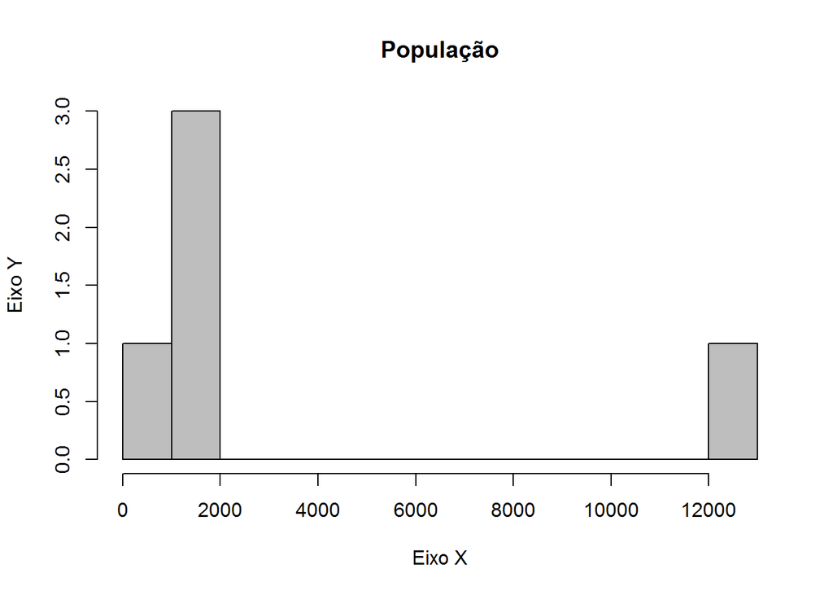

> ```r
> hist(dfA$População,
>     main="População",
>     xlab="Eixo X",
>     ylab="Eixo Y",
>     col="grey",
>     breaks=10)
> ```

## 2. Boxplot

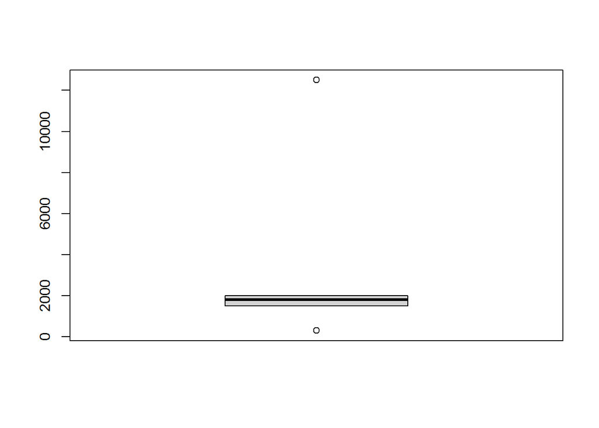

> ```r
> boxplot(dfA$População)
> ```

> >Note que na coluna **População** existem valores muito distantes da média, então vamos utilizar a função *filter()* para remover tais valores apenas para demonstrar o uso desta função no caso de *outliers* (valores discrepantes).

> ```r
> dfB <- dfA %>%
>  filter(População <= 6000)
> ```

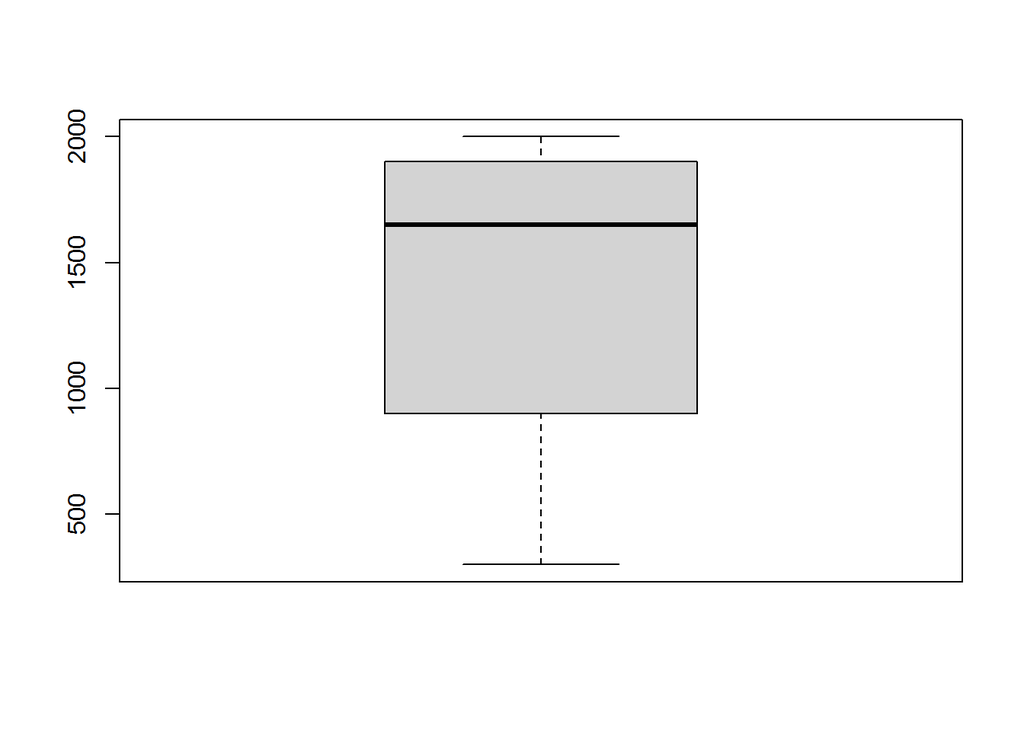

> ```r
> boxplot(dfB$População)
> ```

## 3. Table

### a. verificando a quantidade de ocorrências para cada coluna

> ```r
> table(dfA$Município)
> ```

> ```
> ##
> ## Campo Grande       Cuiabá     Curitiba      Miranda    São Paulo
> ##            1            1            1            1            1
> ```

> ```r
> table(dfA$UF)
> ```

> ```
> ##
> ## MS MT PR SP
> ##  2  1  1  1
> ```

> ```r
> table(dfA$UF, exclude="PR")
> ```

> ```
> ##
> ## MS MT SP
> ##  2  1  1
> ```

### b. quantidade de registros

> ```r
> length(table(dfA$Município))
> ```

> ```
> ## [1] 5
> ```

> ```r
> length(table(dfA$UF))
> ```

> ```
> ## [1] 4
> ```

### c. obter proporção das ocorrências pelo total de registros

> ```r
> prop.table(table(dfA$Município))
> ```

> ```
> ##
> ## Campo Grande       Cuiabá     Curitiba      Miranda    São Paulo
> ##          0.2          0.2          0.2          0.2          0.2
> ```

> ```r
> prop.table(table(dfA$UF))
> ```

> ```
> ##
> ##  MS  MT  PR  SP
> ## 0.4 0.2 0.2 0.2
> ```

> ```r
> prop.table(table(dfA$UF))*100
> ```

> ```
> ##
> ## MS MT PR SP
> ## 40 20 20 20
> ```

> > Na última linha o valor foi convertido em percentual

## 4. Gráfico de Barras

> População por cidade

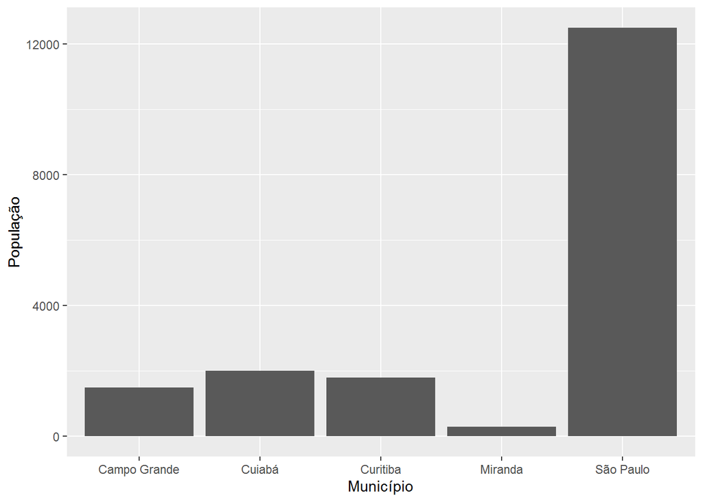

> ```r
> #library(ggplot2)
> ggplot(dfA, aes(x=Município, y=População))+
>  geom_bar(stat='identity')
> ```

> >Neste exemplo utilizamos a classe **gglplot** para criar o gráfico de barras.

> População por Unidade da Federação

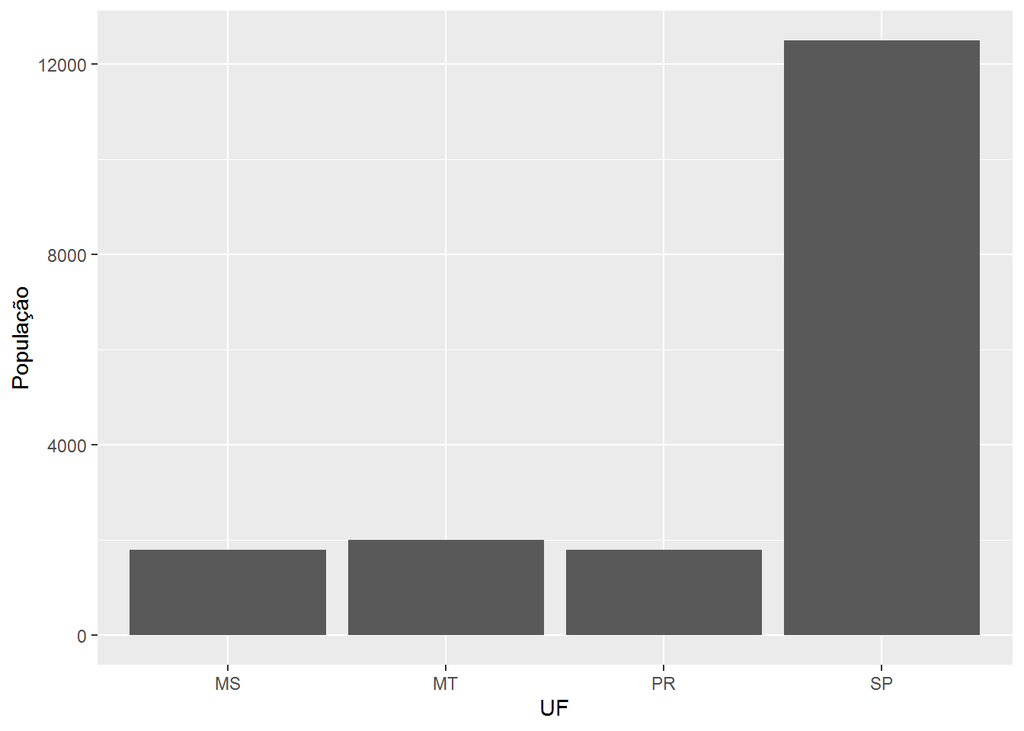

> ```r
> ggplot(dfA, aes(x=UF, y=População))+
>  geom_bar(stat='identity')
> ```

## 5. Gráfico de Barras Invertidas

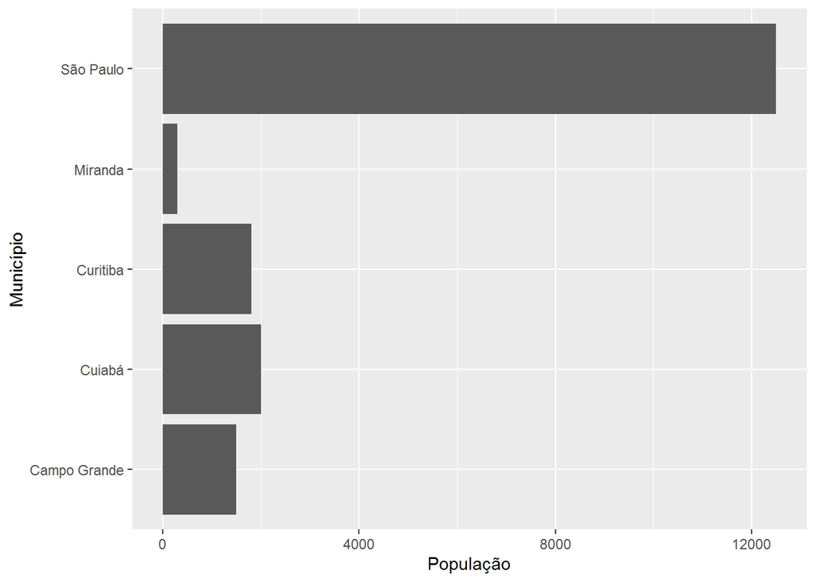

> ```r
> ggplot(dfA, aes(x=Município, y=População))+
>  geom_bar(stat='identity')+
>  coord_flip()
> ```

> >O comando *coord_flip()* converte para barra invertida.

### a. adicionar rótulos de dados

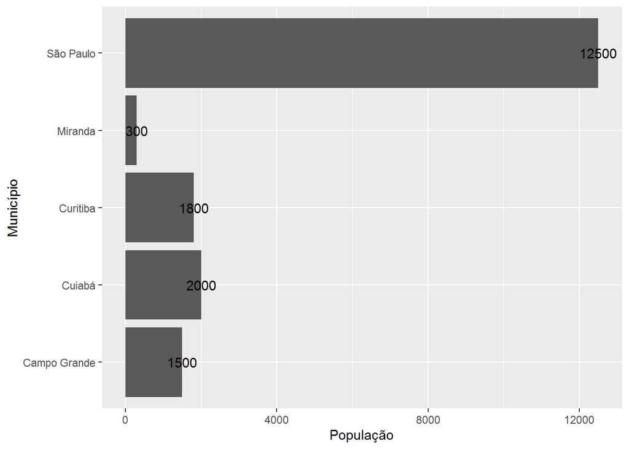

> ```r
> ggplot(dfA, aes(x=Município, y=População))+
>  geom_bar(stat='identity')+
>  geom_text(aes(label=População))+
>  coord_flip()
> ```

### b. Ajustar posição dos rótulos de dados

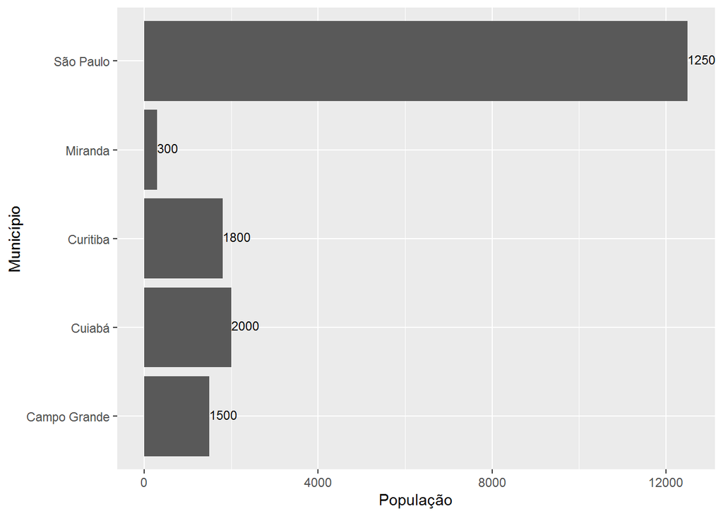

> ```r
> ggplot(dfA, aes(x=Município, y=População))+
>  geom_bar(stat='identity')+
>  geom_text(aes(label=População), hjust=0, vjust=0.3, size=3)+
>  coord_flip()
> ```

### c. Formatando título, margens da área do gráfico e outras configurações

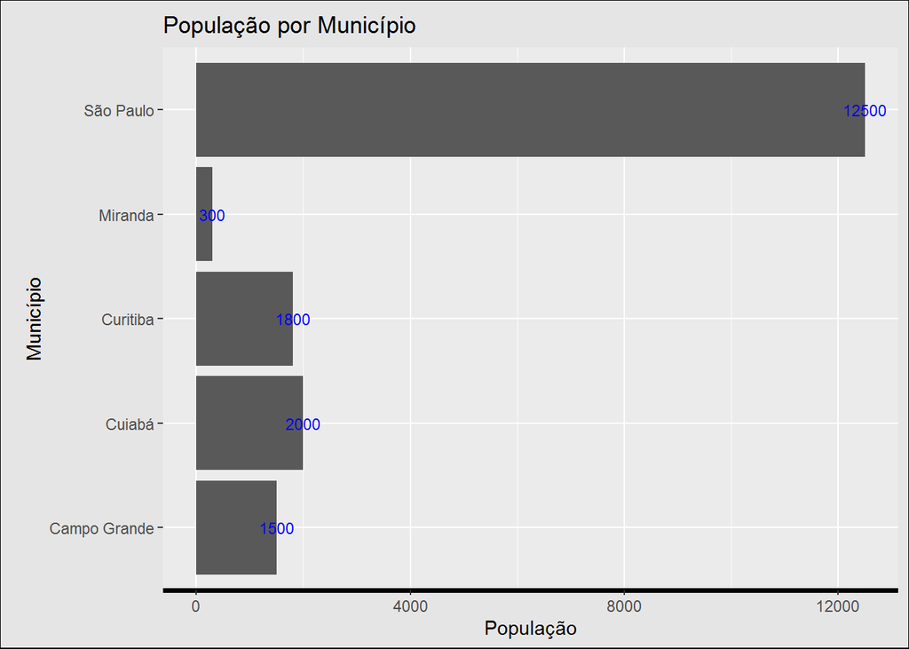

> ```r
> ggplot(dfA, aes(x=Município, y=População))+
>  ggtitle("População por Município")+
>  geom_bar(stat='identity')+
>  geom_text(aes(label=População), hjust=0.5, vjust=0.5, size=3, color="blue")+
>  coord_flip()+ # Muda para barra invertida
>  #theme(axis.title.x=element_text(vjust=-0.5))+
>  #theme(axis.title.y=element_text(angle=90, vjust=-0.5))+
>  theme(plot.margin = unit(c(0.3,0.2,0.2,0.5), "cm"))+
>  #theme(axis.line = element_line(arrow = arrow()))+
>  #theme(axis.line.x = element_line(arrow = arrow()))+
>  theme(axis.line.x = element_line(size=1.25))+
>  theme(plot.background=element_rect(color="black",
>                                     fill = "grey90"))
> ```

### d. Formatando legenda

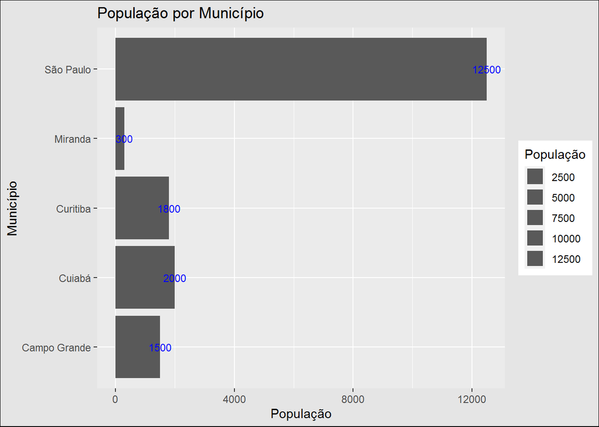

> ```r
> ggplot(dfA, aes(x=Município, y=População, size=População))+
>  ggtitle("População por Município")+
>  geom_bar(stat='identity')+
>  geom_text(aes(label=População), hjust=0.5, vjust=0.5, size=3, color="blue")+
>  coord_flip()+
>  theme(plot.background=element_rect(color="black",
>                                     fill = "grey90"))
> ```

# Dicas

Na janela “*Source*” (local onde digitamos o código), você pode acessar ajuda sobre os pacotes utilizados neste projeto digitanto **?** seguido no nome do pacote, assim:

- **?c** para vetor;
- **?factor** para fator;